# Rankcluster: An R Package for Clustering Multivariate Partial Rankings

The *Rankcluster* package is the first R package proposing both modeling and clustering tools for ranking data, potentially multivariate and partial. Ranking data are modeled by the Insertion Sorting Rank (isr) model, which is a meaningful model parametrized by a central ranking and a dispersion parameter. A conditional independence assumption allows multivariate rankings to be taken into account, and clustering is performed by means of mixtures of multivariate isr models. The parameters of the cluster (central rankings and dispersion parameters) help the practitioners to interpret the clustering. Moreover, the *Rankcluster* package provides an estimate of the missing ranking positions when rankings are partial. After an overview of the mixture of multivariate isr models, the *Rankcluster* package is described and its use is illustrated through the analysis of two real datasets.

Julien Jacques (MODAL team (Inria) & Laboratoire Paul Painlevé (UMR CNRS 8524), University Lille I) , Quentin Grimonprez (MODAL team, Inria Lille-Nord Europe) , Christophe Biernacki (MODAL team (Inria) & Laboratoire Paul Painlevé (UMR CNRS 8524), University Lille I)  
2014-03-03

## 1 Introduction

Ranking data occur when a number of observers are asked to rank a list of objects according to their personal preference order. Such data are of great interest in human activities involving preferences, attitudes or choices like Psychology, Sociology, Politics, Marketing, *etc*. For instance, the voting system *single transferable vote*, used in Ireland, Australia and New Zealand, is based on preferential voting (Gormley and Murphy 2008). In many applications, the study of ranking data discloses heterogeneity, due for instance to different political meanings, different human preferences, *etc*. Clustering analysis is then a useful tool for statistical exploration of such datasets, by characterizing the datasets in terms of a reduced number of clusters within which rankings are similar. In the present work, the clusters will be characterized by a median ranking (location parameter) and by a dispersion parameter. The interpretation of these two parameters for each cluster will produce a comprehensive and synthetic analysis of the whole dataset.

In the present paper we illustrate these ideas with two studies in sociology and in sport. In the sociology study, several students were asked to rank five words according to strength of association (least to most associated) with the target word "Idea": Thought, Play, Theory, Dream and Attention. The cluster analysis of the resulting rankings from this study allows the population of students to be characterized in terms of three clusters that can be interpreted (thanks to the parameters specific to each cluster) as follows: scientific students, literary-minded students and a third group of students in an intermediate position between scientific and too literary-minded. The second study focuses on the performance of English football clubs during the last two decades, and more particularly those of the “Big Four” clubs: Manchester United, Liverpool, Arsenal and Chelsea. For this, the rankings of these four clubs at the English championship (Premier League) and according to the UEFA coefficients are analyzed. The cluster analysis exhibits two relatively similar clusters, reflecting a certain stability in the hierarchy between these clubs, except for the position of Chelsea within the hierarchy: it appears that Chelsea obtains better results in the second half of the period 1993-2013, which can be probably explained by the acquisition of the club by a Russian investor in 2003.

Recently, (Jacques and Biernacki 2012) proposed a model-based clustering algorithm in order to analyse and explore such ranking data. This algorithm is able to take into account multivariate rankings (when several rankings are simultaneously observed, as for instance in the sport application in which rankings at the Premier League and rankings according to the UEFA coefficient are observed simultaneously each year) with potential partial rankings (when an observer did not rank all the objects). To the best of our knowledge, this is the only clustering algorithm for ranking data with such a wide application scope. This algorithm is based on an extension of the Insertion Sorting Rank (isr) model (Biernacki and Jacques 2013) for ranking data, which is a meaningful and effective model obtained by assuming that the ranking generating process is a sorting algorithm. The isr model is parametrized by a location parameter, the modal ranking, and a dispersion parameter. The heterogeneity of the rank population is modeled by a mixture of isr models and a conditional independence assumption allows the extension to multivariate rankings. Maximum likelihood estimation is performed through a SEM-Gibbs algorithm, in which partial rankings are considered as missing data, which allows them to be simulated during the estimation process.

This algorithm has been implemented in C++ and is available through the [*Rankcluster*](https://CRAN.R-project.org/package=Rankcluster) package for R, available on the CRAN website and presented in depth in the sequel of this paper.

The paper is organized as follows: the next section briefly presents the clustering algorithm proposed in (Jacques and Biernacki 2012). Then, the following sections describe the existing R packages dedicated to ranking data, and the functionality of the *Rankcluster* package. The *Rankcluster* package is then illustrated through the cluster analysis of two datasets: 1. The *words* dataset of Fligner and Verducci (1986) featuring univariate rankings without any missing ranking positions, and 2. the rankings of the Big Four English Football clubs (Manchester United, Liverpool, Arsenal and Chelsea) according to the Premier League results and to their UEFA coefficients between 1993 and 2013, featuring bivariate rankings with some missing ranking positions.

## 2 Overview of the model-based clustering algorithm

This section gives an overview of the model-based clustering algorithm for multivariate partial rankings proposed in (Jacques and Biernacki 2012). It relies on the univariate isr model that we introduce first.

### 2.1 The univariate ISR model

Rank data arise when judges or observers are asked to rank several objects $\mathcal{O}_1,\ldots,\mathcal{O}_m$ according to a given order of preference. The resulting ranking can be designated by its *ordering* representation $x=(x^1,\ldots,x^m)\in\mathcal{P}_m$ which signifies that Object $\mathcal{O}_{x^h}$ is the $h$th ($h=1,\ldots,m$), where $\mathcal{P}_m$ is the set of the permutations of the first $m$ integers, or by its *ranking* representation $x^{-1}=(x_1^{-1},\ldots,x_m^{-1})$, which contains the ranks assigned to the objects and means that $\mathcal{O}_i$ is in $x_i^{-1}$th position ($i=1,\ldots,m$). In the *Rankcluster* package, the ranking representation is used, but users working with the ordering representation can use a function implemented in the package in order to convert their data from one representation to the other.

Based on the assumption that a rank datum is the result of a sorting algorithm based on paired comparisons, and that the judge who ranks the objects uses insertion sort because of its optimality properties (minimum number of paired comparisons), (Biernacki and Jacques 2013) stated the following so-called isr model:

$$\label{eq:model}
p(x;\mu,\pi) = \frac{1}{m!} \sum_{y\in \mathcal{P}_m}p(x|y;\mu,\pi)
= \frac{1}{m!} \sum_{y\in \mathcal{P}_m} \pi^{G(x,y,\mu)}(1-\pi)^{A(x,y)-G(x,y,\mu)}, \tag{1}$$

where

- $\mu\in\mathcal{P}_m$, the modal ranking, is a *location parameter*. Its *opposite* ranking $\bar{\mu}$ ($\bar{\mu}=\mu\circ \bar e$ with $\bar e=(m,\ldots,1)$) is the rank of smallest probability,
- $\pi\in[\frac{1}{2},1]$ is the probability of good paired comparison in the sorting algorithm (where good means in accordance with the modal ranking $\mu$). It is a *scale parameter*: the distribution is uniform when $\pi=\frac{1}{2}$ and the mode $\mu$ of the distribution is uniformly more pronounced as $\pi$ grows, being a Dirac function in $\mu$ when $\pi=1$,
- the sum over $y\in \mathcal{P}_m$ corresponds to all the possible initial presentation orders of the objects to be ranked (with identical prior probabilities equal to $1/m!$ because they are unknown),
- $G(x,y,\mu)$ is the number of good paired comparisons during the sorting process leading to return $x$ when the presentation order is $y$,
- $A(x,y)$ corresponds to the total number of paired comparisons (good or wrong).

The precise definitions of $G(x,y,\mu)$ and $A(x,y)$ can be found in (Biernacki and Jacques 2013).

### 2.2 Mixture of multivariate ISR

Now redefine $\mathbf{x}=(x^1,\ldots,x^J)\in \mathcal{P}_{m_1}\times\ldots\times \mathcal{P}_{m_J}$ as a *multivariate* rank, in which $x^j=(x^{j1},\ldots,x^{jm_j})$ is a rank of $m_j$ objects ($1\leq j \leq J$).

The population of multivariate ranks is assumed to be composed of $K$ groups in proportions $p_k$ ($p_k\in[0,1]$ and $\sum_{k=1}^{K}p_k=1$). Given a group $k$, the $J$ components $x^1,\ldots,x^J$ of the multivariate rank datum $\mathbf{x}$ are assumed to be sampled from independent isr distributions with corresponding modal rankings $\mu^1_k,\ldots,\mu^{J}_k$ (each $\mu^j_k\in\mathcal{P}_{m_j}$) and good paired comparison probabilities $\pi^{1}_k,\ldots,\pi^{J}_k\in[\frac{1}{2},1]$.

The unconditional probability of a rank $\mathbf{x}$ is then

$$\label{eq:model-melange}
p(\mathbf{x};\boldsymbol{\theta}) = \sum_{k=1}^{K}p_k\prod_{j=1}^{J} p(x^j;\mu^{j}_k,\pi^{j}_k), \tag{2}$$

where $\boldsymbol{\theta}=(\pi^{j}_k,\mu^{j}_k,p_k)_{k=1,\ldots,K\,, j=1,\ldots,J}$ and $p(x^j;\mu^{j}_k,\pi^{j}_k)$ is defined by ((1)).

Each component $x^j$ of $\mathbf{x}$ can be full or partial. Frequently, the objects in the top positions will be ranked and the missing ones will be at the end of the ranking, but our model does not impose this and is able to work with partial rankings whatever the positions of the missing data (see details in (Jacques and Biernacki 2012)).

### 2.3 Estimation algorithm

Parameter estimation is performed by maximum likelihood. However, maximum likelihood estimation is not straightforward since the model contains some missing data: the cluster memberships $z_i$ of the observations, the presentation orders $\mathbf{y}_i$ (where $\mathbf{y}_i=(y^1_i,\ldots,y^J_i)$ is the presentation order for the $i$th observation) and the unobserved ranking positions, denoted by $\hat{\mathbf{x}}_i$ (for partial rankings). In such a situation, a convenient way to maximize the likelihood is to consider an EM algorithm (Dempster et al. 1977). This algorithm relies on the completed-data log-likelihood, and proceeds by iterating an estimation (E) step, in which the conditional expectation of the completed-data log-likelihood is computed, and a maximization (M) step, in which the model parameters are estimated by maximizing the conditional expectation computed in the E step. Unfortunately, the EM algorithm is tractable only for univariate full rankings with moderate $m$ ($m\leq 7$) for mathematical and numerical reasons. In particular, when partial rankings occur, the E step is intractable since the completed-data log-likelihood is not linear for all three types of missing data (refer to (Jacques and Biernacki 2012) for its expression). A Stochastic EM (SEM) Gibbs approach is then proposed in (Jacques and Biernacki 2012) to overcome these problems.

The fundamental idea of the SEM-Gibbs algorithm is to reduce the computational complexity that is present in both E and M steps of EM by removing all explicit and extensive use of the conditional expectations of any product of missing data. First, it relies on the SEM algorithm (Geman and Geman 1984; Celeux and Diebolt 1985) which generates the latent variables at a so-called stochastic (S) step from the conditional probabilities computed at the E step. Then these latent variables are directly used in the M step. Second, the advantage of the SEM-Gibbs algorithm in comparison with the basic SEM one is that the latent variables are generated without calculating conditional probabilities at the E step, thanks to a Gibbs algorithm. Refer to (Jacques and Biernacki 2012) for more details.

## 3 Existing R packages for ranking data

To the best of our knowledge, there are only two packages dedicated to the analysis of ranking data, available on the CRAN website, but their functionalities are significantly limited in comparison to our package *Rankcluster*, as we discuss now:

- The [*pmr*](https://CRAN.R-project.org/package=pmr) package (Lee and Yu 2013) provides some descriptive statistics and modeling tools using classical rank data models for full univariate ranking data: Luce models, distance-based models, and rank-ordered logit (see (Marden 1995) for a description of these models). Visualization of ranking data using polytopes is also available for less than four objects to rank ($m\leq 4$).
- The [*RMallow*](https://CRAN.R-project.org/package=RMallow) package (Gregory 2012) performs clustering of univariate ranking data using mixtures of distance-based models (Murphy and Martin 2003).

*Rankcluster* proposes modeling and clustering tools on the basis of the mixture of multivariate isr presented in the previous section. Comparing to the existing packages, *Rankcluster* is the only package taking into account multivariate and partial ranking data.

## 4 Overview of the *Rankcluster* functions

This section presents briefly the functions of the *Rankcluster* package. For more details, refer to the help of the functions.

### 4.1 The main function: `rankclust()`

The `rankclust()` function performs modeling or cluster analysis of a dataset of rankings. For cluster analysis, the number of clusters can be specified by the user, or selected by the Bayesian Information Criterion (BIC) (Schwarz 1978), or the Integrated Completed Likelihood (ICL) (Biernacki et al. 2000) in a list of possible numbers provided by the user. By default, the number of clusters is equal to one, and consequently a single homogeneous multivariate isr model is fitted to the data. The main inputs and outputs are described below.

This function has only one mandatory argument, `data`, which is a matrix composed of the $n$ observed ranks in their ranking representation. For **univariate rankings** the number of columns of `data` is $m$ (default value of argument `m`). For **multivariate rankings**, `data` has $m_1+\ldots+m_J$ columns: the first $m_1$ columns contain $x^1$ (first dimension), the columns $m_1+1$ to $m_1+m_2$ contain $x^2$ (second dimension), and so on. In this case, the argument `m` must be filled with the vector of size $(m_1,\ldots,m_j)$. Several arguments allow the different tuning parameters used in the SEM-Gibbs estimation to be specified. Refer to Jacques and Biernacki (2012) and to `help(rankclust)` for more details (section 5 also gives some examples). The option `run` allows the number of initializations of the SEM-Gibbs algorithm to be set (1 by default). In the case of multiple initializations, the best solution according to the approximated log-likelihood is retained.

The `rankclust()` function returns an instance of the `"ResultTab"` class. It contains 5 slots, including `results` which is a list containing all $k=1,\ldots,K$ classes, summarized in 18 slots, among which the main ones are:

- `proportion`: a $K$-vector of proportions $p_1,\ldots,p_K$.
- `pi`: a $K\times J$-matrix composed of the scale parameters $\pi^{j}_{k}$ ($1\leq k \leq K$ and $1\leq j \leq J$).
- `mu`: a matrix with $K$ lines and $m_1+\ldots+m_J$ columns in which line $k$ is composed of the location parameters $(\mu^{1}_{k},\ldots,\mu^{J}_{k})$ of cluster $k$.
- `ll, bic, icl`: values of the log-likelihood, BIC and ICL, respectively.
- `tik`: an $n\times K$ matrix containing the estimates of the conditional probabilities of belonging to each cluster for the observed ranks.
- `partition`: an $n$-vector containing the partition estimate resulting from the clustering.
- `partialRank`: a matrix containing the full rankings, estimated using the within cluster isr parameters when the ranking is partial.
- `distanceProp, distancePi, distanceMu`: distances between the final estimate and the current value at each iteration of the SEM-Gibbs algorithm (except the burn-in phase) for respectively: proportions $p_k$, scale parameters $\pi^{j}_{k}$, location parameters $\mu^{j}_{k}$.
- `distanceZ`: a vector of size `Qsem-Bsem` containing the Rand index (Rand 1971) between the final estimated partition and the current value at each iteration of the SEM-Gibbs algorithm (except the burning phase).

If `res` is the name assigned to the result of `rankclust()`, each slot can be obtained by `res[k]@slotname`, where `k` is the cluster index and `slotname` is the name of the selected slot (`proportion`, `pi` ...). For the slots `ll`, `bic` and `icl`, `res["slotname"]` returns a vector of size $K$ containing the values of the slot for each cluster index.

### 4.2 Companion functions

In addition to the main function, `rankclust()`, several companion functions are available in *Rankcluster*:

- `convertRank()`: converts ranking representation $x^{-1}$ of a rank to its ordering representation $x$, and *vice-versa* since $x \circ x^{-1}=x^{-1}\circ x$.
- `distCayley(), distHamming(), distKendall(), distSpearman()`: compute usual distances between rankings (Marden 1995) for either ranking or ordering representation.
- `frequence()`: transforms a raw dataset composed of a matrix of ranks (one rank per line, with possibly equal lines if the same rank is observed several times) into a matrix rank/frequency containing in line each different observed ranks and one additional last column with the frequency of observation of these ranks. Conversely, `unfrequence()` transforms a rank/frequency dataset in a raw dataset, as requested in input argument of `rankclust()`.
- `khi2()`: performs a chi-squared goodness-of-fit tests and returns the p-value of the test (See (Biernacki and Jacques 2013) for details).
- `kullback()`: estimates the Kullback-Leibler divergence between two isr models.
- `simulISR()`: simulates a univariate and unimodal dataset of full rankings according to the isr model.
- `probability()`: computes the probability of a ranking (multivariate or not) according to the isr model.

## 5 *Rankcluster* through examples

This section illustrates the use of the `rankclust()` function on two real datasets. The first one, `words`, is a well-known dataset in ranking studies, due to (Fligner and Verducci 1986), which consists of words associations by students. The second one, `big4` consists of the rankings of the Big Four of English Football (Manchester United, Liverpool, Arsenal and Chelsea) according to the Premier League results and to their UEFA coefficients between 1993 and 2013.

### 5.1 The `words` dataset

This dataset was collected under the auspices of the Graduate Record Examination Board (Fligner and Verducci 1986). A sample of 98 college students were asked to rank five words according to strength of association (least to most associated) with the target word "Idea": 1 = Thought, 2 = Play, 3 = Theory, 4 = Dream and 5 = Attention.

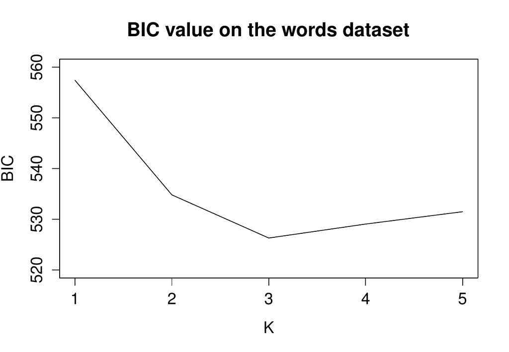

Figure 1: Value of the BIC criterion with mixture of isr for the `words` dataset.

First we start by installing and loading the *Rankcluster* package and then loading the `words` dataset:

```r
R> install.packages("Rankcluster")
R> library(Rankcluster)
R> data(words)
```

Using the `rankclust()` function, a clustering with respectively $1$ to $5$ clusters is estimated:

```r
R> res=rankclust(words$data, m=words$m, K=1:5, Qsem=1000, Bsem=100, Ql=500, Bl=50,
+  maxTry=20, run=10)
```

```r
R> res=rankclust(words$data, m=words$m, K=1:5, Qsem=200, Bsem=20, Ql=200, Bl=20,
+  maxTry=20)
```

The values of the BIC criterion, obtained by `res["bic"]` and plotted on Figure 1, tend to select three clusters.

The parameter estimates for $K=3$ are given below for proportions $p_k$, scales $\pi_k$ and modes $\mu_k$:

```r
R> res[3]@proportion
[1] 0.3061224 0.4918367 0.2020408
R> res[3]@pi
         dim 1
cl 1 0.9060649
cl 2 0.9416822
cl 3 0.8642753
R> res[3]@mu
     dim 1
cl 1     5 1 3 4 2
cl 2     5 1 4 3 2
cl 3     5 2 4 3 1
```

The word Thought is most associated with Idea for all clusters. Looking at the rankings of the four other words can suggest an interesting interpretation of the clusters. Indeed, the first cluster, composed of about $30\%$ of the students, is characterized by the following modal ranking: Play, Attention, Theory, Dream, Thought. Students in this cluster are probably literary-minded students who rank the word Dream just after Thought. Students in the second cluster (about half of total students) are probably more scientific since they rank the word Theory just after Thought, and so before the word Dream: Play, Attention, Dream, Theory, Thought. This cluster is also the most homogeneous, with a high scale parameter value (low dispersion): $\pi_2\simeq 0.94$. Finally, the last cluster is characterized by the following mode: Attention, Play, Dream, Theory, Thought. The only difference in the modal ranking with the scientific students is the preference of Play rather than Attention. This cluster, which is the smallest ($20\%$ of the students), can be qualified as intermediate cluster, probably composed of a set of students not too scientific or too literary-minded, as evidenced by the smallest of the three scale parameter values ($\pi_3\simeq 0.86$).